# ME414 - Estatística para Experimentalistas

## Probabilidade Condicional e Independência

## Probabilidade condicional

**Probabilidade Condicional**: encontrar a probabilidade de um evento quando você tem alguma outra informação sobre o evento.

- Considere o lançamento de dois dados. Espaço amostral:

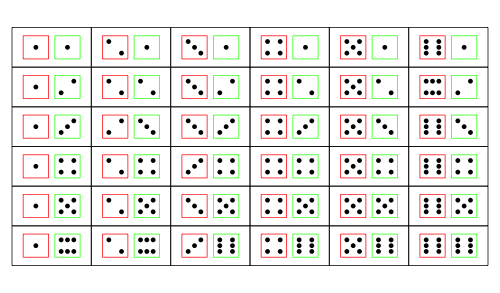

- Considere que cada resultado tenha a mesma chance de ocorrer: 1/36.
- Suponha que você lance primeiro um dos dados e o resultado é 4.
- Qual a probabilidade de que a soma dos resultados dos dois dados seja 10?

## Probabilidade condicional

- Como saiu 4 no primeiro dado, há 6 resultados possíveis:

> \[\Omega_1=\{(4,1),(4,2),(4,3),(4,4),(4,5),(4,6)\}\]
- Cada resultado tem a mesma probabilidade de ocorrer: 1/6.
- Dado que o primeiro dado teve resultado 4, então a probabilidade de cada evento em \(\Omega_1\) tem igual chance de ocorrer.
- \(B\) = {a soma dos dados é igual a 10}.
- \(A\) = {no primeiro dado saiu 4}.
- **Probabilidade condicional de \(B\) dado \(A\):** \[P(B\mid A)\]

## Probabilidade condicional \(P(B\mid A)\)

- Suponha que o resultado do experimento esteja contido no evento \(A\).
- Para que o resultado esteja também no evento \(B\), ele precisa necessariamente estar tanto em \(A\) quanto em \(B\), ou seja, precisa estar em \(A\cap B\).
- Mas, como sabíamos desde o início que o resultado estava em \(A\), nosso espaço amostral agora é reduzido para somente os elementos de \(A\).

> \[P(B\mid A)=\frac{P(A\cap B)}{P(A)}\]

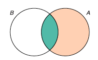

## Exemplo: Lançamento de dois dados

> Voltando ao exemplo dos dois dados.
- \(A\) = no primeiro dado saiu 4.

> \[ A = \{(4,1), (4,2), (4,3), (4,4), (4,5), (4,6)\}\]
- \(B\) = a soma dos dados é igual a 10.

> \[ B = \{(4,6), (5,5), (6,4)\}\]
- Então \(A\cap B = \{(4,6) \}\). Portanto:

> \[ P(B\mid A)= \frac{P(A\cap B)}{P(A)} = \frac{1/36}{6/36}= \frac{1}{6}\]

## Exemplo: Qual a chance de cair na malha fina?

80.2 milhões de declarações.

Tabela : Renda x Malha Fina

|  | Sim | Não | Total |
| --- | --- | --- | --- |
| D - abaixo de 25.000 | 90 | 14010 | 14100 |
| C - 25.000 a 49.999 | 71 | 30629 | 30700 |
| B - 50.000 a 99.999 | 69 | 24631 | 24700 |
| A - acima de 100.000 | 80 | 10620 | 10700 |
| Total | 310 | 79890 | 80200 |

Para simplificar, uma frequência de 90 representa 90.000.

## Exemplo: Qual a chance de cair na malha fina?

- Espaço amostral:

> \[ \Omega=\{\mbox{(A, sim), (B,sim),(C, sim),(D,sim),(A,não),(B,não),(C,não),(D,não)} \}\]
- Qual a probabilidade de cair na malha fina se a renda for acima de 100.000?
- \(\mathcal{A}\) = {caiu na malha fina} =\(\{ \mbox{(A,sim),(B,sim),(C,sim),(D,sim)} \}\)
- \(\mathcal{B}\) = {renda acima de 100.000} =\(\{\mbox{ (A,sim),(A,não)} \}\).

> \[ P(\mathcal{A} \mid \mathcal{B}) = \frac{P(\mathcal{A} \cap \mathcal{B})}{P(\mathcal{B})} = \frac{P(\{\mbox{(A,sim)}\})}{P(\{\mbox{(A,sim),(A,não})\})} \]

> \[ =\frac{80/80200}{10700/80200}=0.007 \]

## Exemplo: Qual a chance de cair na malha fina?

Probabilidade condicional por faixa de renda em 2002

| Renda | Sim | Não |
| --- | --- | --- |
| D - abaixo de 25.000 | 90/14100 | 14010/14100 |
| C - 25.000 a 49.999 | 71/30700 | 30629/30700 |
| B - 50.000 a 99.999 | 69/24700 | 24631/24700 |
| A - acima de 100.000 | 80/10700 | 10620/10700 |

## Exemplo: Qual a chance de cair na malha fina?

Probabilidade condicional por faixa de renda em 2002

| Renda | Sim | Não |
| --- | --- | --- |
| D - abaixo de 25.000 | 0.006 | 0.994 |
| C - 25.000 a 49.999 | 0.002 | 0.998 |
| B - 50.000 a 99.999 | 0.003 | 0.997 |
| A - acima de 100.000 | 0.007 | 0.993 |

## Independência

Vimos que: \[P(B\mid A)=\frac{P(A\cap B)}{P(A)}\]

**Regra da multiplicação:**

\[P(A\cap B)=P(A)P(B\mid A)\]

Quando \(P(B\mid A)=P(B)\) (informação sobre \(A\) não altera a probabilidade do evento \(B\)), dizemos que \(B\) e \(A\) são **independentes**. Neste caso:

\[P(A\cap B)=P(A)P(B) \]

## Exemplo

Considere o lançamento de dois dados "justos" (36 resultados possíveis têm a mesma probabilidade de ocorrer).

Considere os eventos:

- \(A\): primeiro dado tem resultado 3.
- \(B\): soma dos dados é igual a 8.
- \(C\): soma dos dados é igual a 7.

## Exemplo

Eventos \(A\) e \(B\) são independentes?

\(P(A\cap B)= P(\{(3,5)\})=\frac{1}{36}\)

\(P(A)= P(\{ (3,1),(3,2),(3,3),(3,4),(3,5),(3,6)\})=\frac{6}{36}\)

\(P(B)= P(\{ (2,6),(3,5),(4,4),(5,3),(6,2)\})=\frac{5}{36}\)

\[P(A\cap B)=\frac{1}{36}\neq P(A)\times P(B)=\frac{6}{36}\times\frac{5}{36}\]

Portanto, \(A\) e \(B\) não são eventos independentes.

## Exemplo

Ainda no mesmo exemplo: os eventos \(A\) e \(C\) são independentes?

\(P(A\cap C)= P(\{(3,4)\})=\frac{1}{36}\)

\(P(A)= P(\{ (3,1),(3,2),(3,3),(3,4),(3,5),(3,6)\})=\frac{6}{36}\)

\(P(C)= P(\{ (1,6),(2,5),(3,4),(4,3),(5,2),(6,1)\})=\frac{6}{36}\)

\[P(A\cap C)=\frac{1}{36}= P(A)\times P(C)=\frac{6}{36}\times\frac{6}{36}\]

Portanto, \(A\) e \(C\) são eventos independentes.

## Exemplo

Suponha que \(A\) e \(B\) sejam dois eventos disjuntos.

Suponha que \(P(A)>0\) e \(P(B)>0\).

\(A\) e \(B\) são independentes?

\(A\) e \(B\) são disjuntos, então \(A\cap B=\varnothing\) e \(P(A\cap B)=0\).

\(P(A)>0\) e \(P(B)>0\), portanto:

\[P(A\cap B)=0\neq P(A)P(B)\,.\]

\(A\) e \(B\) não são independentes.

Além disso: \(P(B\mid A)=\frac{P(A\cap B)}{P(A)}=0\), ou seja, dado que \(A\) ocorre, \(B\) não ocorre.

## Exemplo

Em uma família com duas crianças, considere os eventos:

\(A\)={a primeira criança é uma menina} e \(B\)={as duas crianças são meninas}.

- Mostre que \(P(B\mid A)=1/2\).

\[\Omega=\{FF,MM,FM,MF\}\]

\[A=\{FF,FM\}\]

\[B=\{FF\}\]

\[B\cap A= B\]

\[P(B\mid A)=\frac{P(B\cap A)}{P(A)}=\frac{P(\{FF\})}{P(\{FF,FM \})}=\frac{1/4}{1/2}=1/2\]

## Exemplo

Em uma família com duas crianças, considere os eventos:

\(A\)={a primeira criança é uma menina} e \(B\)={as duas crianças são meninas}.

- \(A\) e \(B\) são eventos independentes?

\[\Omega=\{FF,MM,FM,MF\}\] \[A=\{FF,FM\}\] \[B=\{FF\}\] \[B\cap A= B\] \[P(B\cap A)=P(B)=1/4\] \[P(A)P(B)=\frac{1}{2}\times\frac{1}{4}=\frac{1}{8}\] \[P(A\cap B)\neq P(A)P(B)\] \(A\) e \(B\) não são independentes.

## *Chutar* as respostas e ainda passar na prova

**Chutar**: escolher as respostas ao acaso

- Prova com três questões de múltipla escolha.
- Em cada questão há 5 alternativas, apenas 1 é correta.
- Experimento: anotar o resultado do aluno na prova.

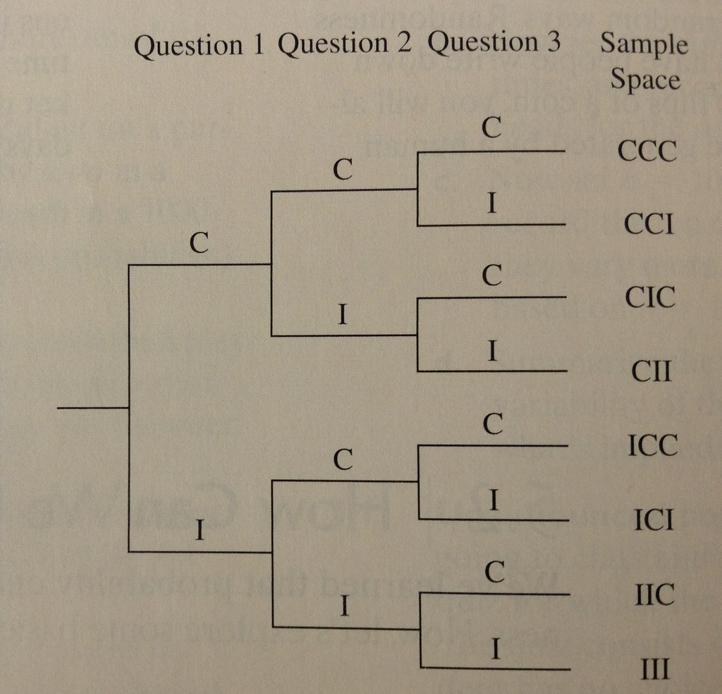

\[\Omega=\{CCC,CCI,CIC,CII,ICC,ICI,IIC,III\}\]

## *Chutar* as respostas e ainda passar na prova

Quais as probabilidades dos eventos do espaço amostral?

- Para cada questão: \(P(C)=0.2\) e \(P(I)=0.8\).
- \(P(CCC)= P(C)\times P(C)\times P(C)=0.2^3=0.008\).

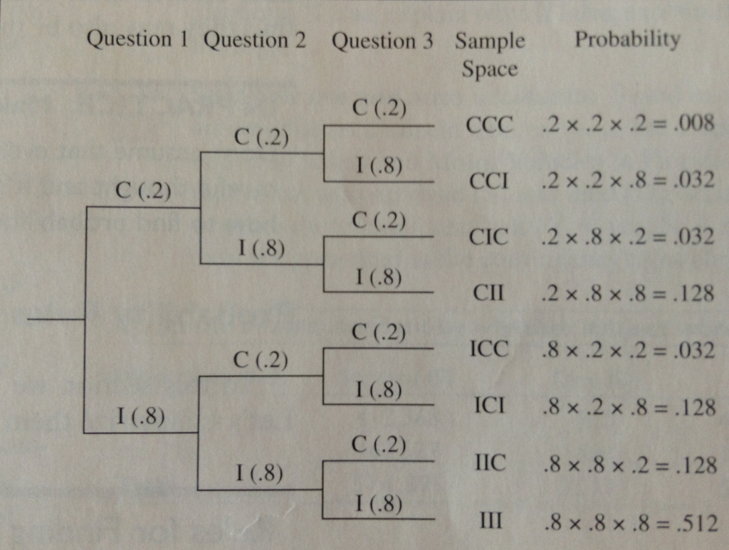

Qual a probabilidade do aluno acertar pelo menos duas questões?

\[P(CCC)+P(CCI)+P(CIC)+P(ICC)=0.008+3\times0.032=0.104\]

## Cinto de segurança e acidentes

[output not shown]

- Qual a probabilidade de que a pessoa morreu no acidente?

\[P(M)=2111/577006=0.004\]

- Qual a probabilidade de que a pessoa morreu dado que ela usava o cinto de segurança?

\[P(M\mid C)=P(M\cap C)/P(C)=510/412878=0.001\]

## Cinto de segurança e acidentes

[output not shown]

- Qual a probabilidade de que a pessoa morreu dado que ela não usava o cinto de segurança?

\[P(M\mid \bar{C})=P(M\cap \bar{C})/P(\bar{C})=1601/164128=0.01\]

- Morte e uso de cinto são eventos independentes?

\[P(M\mid\bar{C})\neq P(M)=2111/577006=0.004\]

\[P(M\mid C)\neq P(M)\]

## Teorema de Bayes

Considere dois eventos quaisquer \(A\) e \(B\).

Para que um elemento esteja em \(A\), há duas possibilidades:

- o elemento está em \(A\) e em \(B\);
- o elemento está em \(A\), mas não está em \(B\).

## Teorema de Bayes

Portanto, podemos escrever:

\[A=(A\cap B) \cup (A\cap B^c)\]

> As duas possibilidades são disjuntas, então: \[P(A)=P(A\cap B)+P(A\cap B^c)\]

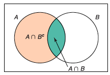

## Teorema de Bayes

Temos que: \[P(A\cap B)=P(A\mid B) P(B)\]

\[P(A\cap B^c)=P(A\mid B^c) P(B^c)\]

Então reescrevemos: \[P(A)=P(A\mid B) P(B)+P(A\mid B^c) P(B^c)\]

**Interpretação**: a probabilidade do evento \(A\) é uma média ponderada da probabilidade condicional do evento \(A\) dado que \(B\) ocorre e da probabilidade condicional do evento \(A\) dado que \(B\) não ocorre. O peso de cada probabilidade condicional é a probabilidade do evento que está sendo levado em conta ao calcular a probabilidade condicional de \(A\).

## Teorema de Bayes

\[P(B\mid A) = \frac{P(B\cap A)}{P(A)} = \frac{P(A\mid B)P(B)}{P(A\mid B)P(B) + P(A\mid B^c)P(B^c)}\]

## Exemplo: Companhia de Seguros

Uma companhia de seguros acredita que as pessoas podem ser divididas em duas categorias:

1. aquelas que estão mais sujeitas a acidentes.
1. aquelas que não estão mais sujeitas a acidentes.
- Os dados indicam que uma pessoa da categoria 1 terá um acidente durante o período de um ano com probabilidade 0.1. A probabilidade para todas as outras pessoas é 0.05.
- Suponha que a probabilidade de um novo cliente pertencer à categoria 1 seja 0.2.

## Exemplo: Companhia de Seguros

**Pergunta**: Qual a probabilidade de que o novo cliente tenha um acidente durante o primeiro ano?

Considere os eventos:

\(A\): o novo cliente tem um acidente durante o primeiro ano.

\(B\): o novo cliente pertence à categoria 1.

\(B^c\): o novo cliente pertence à categoria 2.

> Pelo Teorema de Bayes:

\[ P(A) = P(A\mid B)P(B)+P(A\mid B^c)P(B^c)\] \[ = 0.1\times 0.2 + 0.05\times 0.8 = 0.06 \]

## Exemplo: Companhia de Seguros

**Pergunta**: Se um novo cliente tem um acidente durante o primeiro ano, qual é a probabilidade de que ele pertença à categoria 1?

\(A\): o novo cliente tem um acidente durante o primeiro ano.

\(B\): o novo cliente pertence à categoria 1.

\[ P(B\mid A) = \frac{P(B\cap A)}{P(A)} \]

\[ = \frac{P(A\mid B)P(B)}{P(A)} \]

\[ = \frac{0.1 \times 0.2}{0.06}=\frac{1}{3} \]

## DNA e crime

- Dado que o réu é inocente, suponha que a probabilidade do DNA dele ser compatível com o DNA encontrado na cena do crime seja 1 em um milhão. \[P(Comp\mid Inocente)=0.000001\]
- Dado que o réu é culpado, suponha que a probabilidade do DNA dele ser compatível com o DNA da cena do crime seja 0.99. \[P(Comp\mid Culpado)=0.99\]
- O DNA do réu é compatível com o DNA da cena do crime.
- Encontre a probabilidade do réu ser inocente dado que o DNA é compatível, sendo que a probabilidade incondicional dele ser inocente é 0.5.

> Queremos \(P(Inocente\mid Comp)\), sendo que \(P(Inocente)=P(Culpado)=0.5\)

## DNA e crime

\[ P(Inocente \mid Comp) = \frac{P(Inocente \cap Comp)}{P(Comp)} \]

> \[ = \frac{P(Comp \mid Inocente)P(Inocente)}{P(Comp)} \]

> \[ = \frac{P(Comp \mid Inocente)P(Inocente)}{P(Comp \mid Inocente)P(Inocente) + P(Comp \mid Culpado)P(Culpado)} \]

> \[ = \frac{0.000001 \times 0.50}{0.000001 \times 0.5 + 0.99 \times 0.5} = 0.000001 \]

> A chance de ser inocente dado que houve compatibilidade de DNA é 1 em 1 milhão.

## DNA e crime

Encontre a probabilidade do réu ser inocente dado que o DNA é compatível, sendo que a probabilidade incondicional dele ser inocente é 0.99.

> \[ P(Inocente\mid Comp) = \frac{P(Inocente \cap Comp)}{P(Comp)} \]

> \[ = \frac{P(Comp\mid Inocente)P(Inocente)}{P(Comp)} \]

## Leituras

- [OpenIntro](https://www.openintro.org/stat/textbook.php): seção 2.2.
- [Ross](http://www.sciencedirect.com/science/book/9780123743886): seções 4.5, 4.6
- Magalhães: capítulo 2

[figure not shown]

Slides produzidos pelos professores:

- Samara Kiihl
- Tatiana Benaglia
- Benilton Carvalho